# BIO331 – Lab 08: Phylogenetics

Bioinformatics

Dee Ruttenberg

Mar. 18, 2026

The final project for this semester will be doing phylogenetics in R. We will be using the same data set we used in the last lab.

# Download Required Packages

```r
library(Biostrings)
library(ape)
library(ggtree)
```

I will show you in class how to use Clustal to perform alignment (and you will need to use it to answer a homework problem!). However, the fasta file we worked with yesterday was generated through multiple sequence alignment (this is why it has dashes), so we do not need to use clustal for alignment.

```r
#setwd("~/Documents/GitHub/Bioinformatics2026/lab7-rblast")
#seqs <- readDNAStringSet("Full_cmv_259sequences_Aln.fasta")
```

Generating a distance matrix for a 200,000 nt sequence will fry our computer, so we’re going to just take a subset. We’ll use hamming distance (which basically looks at whether two sites are the same)

```r
#library(Biostrings)
#africa_ids <- grep("Africa", names(seqs), ignore.case = TRUE)
#africa_seqs = seqs[africa_ids]
#subseqs <- subseq(africa_seqs, start = 20000, end = 50000)
#dist_matrix <- stringDist(africa_seqs, method = "hamming")
```

Using this district matrix, we can use the ‘ape’ library to make different kinds of trees (for this one, we will use a neighbor joining algorithm)

```r
#library(ape)
#library(ggtree)
#nj_tree <- nj(dist_matrix)
#plot(nj_tree, main="Neighbor-Joining Tree") Simpler method without ggtree
#ggtree(nj_tree) +
 # geom_tiplab() +
 # ggplot2::xlim(0, 15000) +
  #theme_tree2()
```

# Question 1:

In this question, you will generate a UPGMA phylogeny from the structure of a single gene (NADH Dehydrogenase) in Mus musculus domesticus, the common house mouse. Data from this question will be taken from https://www.ncbi.nlm.nih.gov/pmc/articles/PMC44202/pdf/pnas01136-0122.pdf.

In Table 1, the researchers show the sequence of nucleotides in 16 haplotypes at the ND3 site. We will consider 5 haplotypes (slightly edited to make your answer more elegant-looking):

Hap 1: CTCTTAAATCCTATATTTATTTGATCGA Hap 3: AACGTTCTTAAATCCTATACTTATTTGA Hap 5: CTCTTAAATCCTATGGGATCCATTTGATCGA Hap 7: AACTCTCTTAAGTCCTATTTATGTTTGA Hap 8: ATCGCTCTCAAGTCCTATTTTTATTTGA

Using CLUSTAL, load these 5 haplotypes and create an aligned fasta file . Add the aligned fasta file to the github repository. Using CLUSTAL, I loaded the 5 haplotypes and created an aligned fast file using CLUSTALW. I then saved the file titled mouse_genend3_haplotypes_aligned.fasta # Question 2:

Calculate a distance matrix of these 5 haplotypes, treating each pairwise mutation (including each site in an indel) as a single unit of change. Using the calculated distance matrix, create a Neighbor-Joining tree of these 5 haplotypes. Display this neighbor joining tree with ggtree. Answer: To calculate a distance matrix for these 5 haplotypes,

```r
library(Biostrings)
library(ape)
library(ggtree)
seqs <- readDNAStringSet("mouse_genend3_haplotypes_aligned.fasta")
dist_matrix <- pwalign::stringDist(seqs, method = "hamming")
as.matrix(dist_matrix)
```

```
##      Hap7 Hap8 Hap3 Hap1 Hap5
## Hap7    0    5    7   12   16
## Hap8    5    0    6   11   16
## Hap3    7    6    0   10   15
## Hap1   12   11   10    0    5
## Hap5   16   16   15    5    0
```

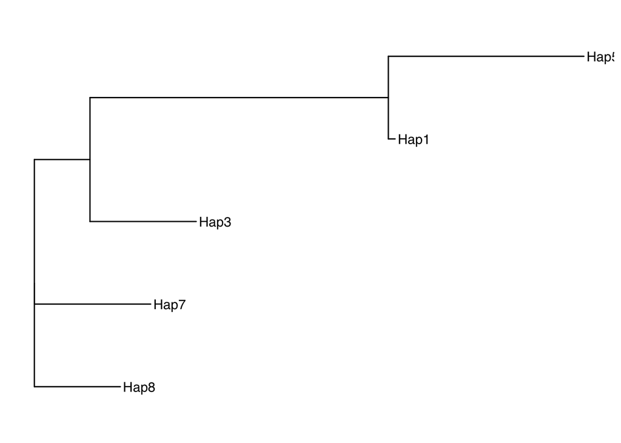

```r
nj_tree <-nj(as.dist (as.matrix(dist_matrix)))
ggtree(nj_tree) + geom_tiplab()
```

# Question 3:

This distance matrix treats each indel its own point mutation. Filter these haplotypes to only contain sites where every haplotype has an associated nucleotide (so no indels), and display the neighbor joining tree for this data set. answer : in order to complete question 3, I had to use google to help me but I first filtered aligned haplotypes by removing the columns that had an indel/ gap. After this, I recalculated the hamming distance matrix only using those nucleotide sites then I created a new neighbor-Joining tree.

```r
seqs <- readDNAStringSet("mouse_genend3_haplotypes_aligned.fasta")
seq_matrix <- do.call(rbind, strsplit(as.character(seqs), ""))
seq_matrix
```

```
##      [,1] [,2] [,3] [,4] [,5] [,6] [,7] [,8] [,9] [,10] [,11] [,12] [,13] [,14]
## Hap7 "A"  "A"  "C"  "T"  "C"  "T"  "C"  "T"  "T"  "A"   "A"   "G"   "T"   "C"
## Hap8 "A"  "T"  "C"  "G"  "C"  "T"  "C"  "T"  "C"  "A"   "A"   "G"   "T"   "C"
## Hap3 "A"  "A"  "C"  "G"  "T"  "T"  "C"  "T"  "T"  "A"   "A"   "A"   "T"   "C"
## Hap1 "-"  "-"  "-"  "-"  "C"  "T"  "C"  "T"  "T"  "A"   "A"   "A"   "T"   "C"
## Hap5 "-"  "-"  "-"  "-"  "C"  "T"  "C"  "T"  "T"  "A"   "A"   "A"   "T"   "C"
##      [,15] [,16] [,17] [,18] [,19] [,20] [,21] [,22] [,23] [,24] [,25] [,26]
## Hap7 "C"   "T"   "A"   "T"   "-"   "-"   "-"   "T"   "T"   "A"   "T"   "G"
## Hap8 "C"   "T"   "A"   "T"   "-"   "-"   "-"   "T"   "T"   "T"   "T"   "A"
## Hap3 "C"   "T"   "A"   "T"   "-"   "-"   "-"   "A"   "C"   "T"   "T"   "A"
## Hap1 "C"   "T"   "A"   "T"   "-"   "-"   "-"   "A"   "T"   "T"   "T"   "A"
## Hap5 "C"   "T"   "A"   "T"   "G"   "G"   "G"   "A"   "T"   "C"   "C"   "A"
##      [,27] [,28] [,29] [,30] [,31] [,32] [,33] [,34] [,35]
## Hap7 "T"   "T"   "T"   "G"   "A"   "-"   "-"   "-"   "-"
## Hap8 "T"   "T"   "T"   "G"   "A"   "-"   "-"   "-"   "-"
## Hap3 "T"   "T"   "T"   "G"   "A"   "-"   "-"   "-"   "-"
## Hap1 "T"   "T"   "T"   "G"   "A"   "T"   "C"   "G"   "A"
## Hap5 "T"   "T"   "T"   "G"   "A"   "T"   "C"   "G"   "A"
```

```r
keep_cols <- apply(seq_matrix, 2, function(col) all(col != "-"))
keep_cols
```

```
##  [1] FALSE FALSE FALSE FALSE  TRUE  TRUE  TRUE  TRUE  TRUE  TRUE  TRUE  TRUE
## [13]  TRUE  TRUE  TRUE  TRUE  TRUE  TRUE FALSE FALSE FALSE  TRUE  TRUE  TRUE
## [25]  TRUE  TRUE  TRUE  TRUE  TRUE  TRUE  TRUE FALSE FALSE FALSE FALSE
```

```r
filtered_matrix <- seq_matrix[, keep_cols]

filtered_seqs <- DNAStringSet(apply(filtered_matrix, 1, paste0, collapse = ""))
names(filtered_seqs) <- names(seqs)

filtered_seqs
```

```
## DNAStringSet object of length 5:
##     width seq                                               names
## [1]    24 CTCTTAAGTCCTATTTATGTTTGA                          Hap7
## [2]    24 CTCTCAAGTCCTATTTTTATTTGA                          Hap8
## [3]    24 TTCTTAAATCCTATACTTATTTGA                          Hap3
## [4]    24 CTCTTAAATCCTATATTTATTTGA                          Hap1
## [5]    24 CTCTTAAATCCTATATCCATTTGA                          Hap5
```

```r
filtered_dist_matrix <- pwalign::stringDist(filtered_seqs, method = "hamming")

as.matrix(filtered_dist_matrix)
```

```
##      Hap7 Hap8 Hap3 Hap1 Hap5
## Hap7    0    3    6    4    5
## Hap8    3    0    5    3    5
## Hap3    6    5    0    2    4
## Hap1    4    3    2    0    2
## Hap5    5    5    4    2    0
```

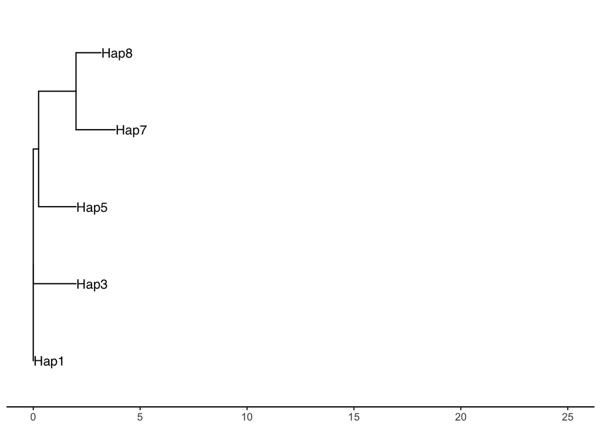

```r
filtered_nj_tree <- nj(as.dist(as.matrix(filtered_dist_matrix)))

ggtree(filtered_nj_tree) +
  geom_tiplab() +
  ggplot2::xlim(0, 25) +
  theme_tree2()
```